# STAT 430 : Challenge 5

Avinash B

### Excercise 1 : Titanic Data

#### Data preprocessing:

This loads the required libraries for the assignment and also loads in the data from the “Titanic” dataset. The dataset in its raw form is a 4-D array giving the cross tabulation of the number of passengers based on the following features: Class,Sex,Age,Survived. The 4-D array is converted into a dataframe.

```r
pckgs = c("dplyr","treemap","streamgraph","ggplot2","babynames")
pkgs_loaded = lapply(pckgs, require, character.only=T)

data(Titanic)
d <- Titanic
d <- as.data.frame(d)
```

#### A) Tree map By Sex

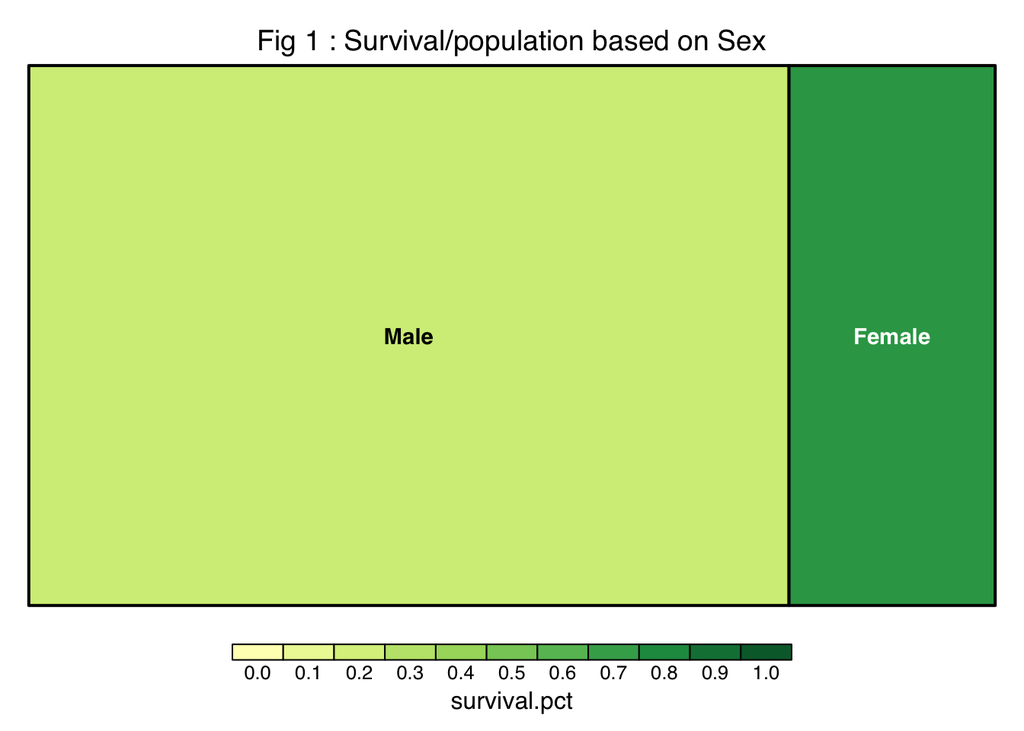

```r
# A) By Sex ####

by.sex<-as.data.frame(d %>%
  group_by(Sex,Survived) %>%
  summarise(k = sum(Freq)) %>%
  mutate(survival.pct = k/sum(k),total = sum(k)) %>%
  filter(Survived == "Yes"))

treemap(by.sex,
        index=c("Sex"),
        vSize="total",
        vColor="survival.pct",
        type="value",
        range = c(0,1),
        title = "Fig 1 : Survival/population based on Sex")
```

We can See from the treemap that there were more male than Females on-board the Titanic, but the survival percentage of Females (~ 75%) is much higher than that of male (~ 25%).

#### B) Tree map By Age

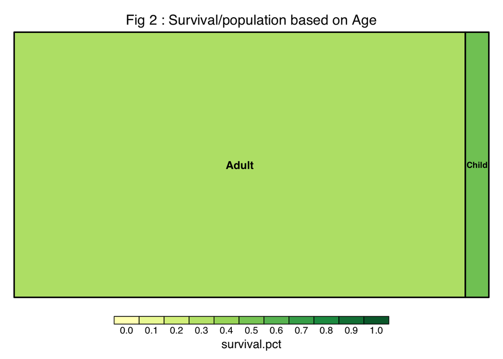

```r
# B) By Age ####
by.age<-as.data.frame(d %>%
                        group_by(Age,Survived) %>%
                        summarise(k = sum(Freq)) %>%
                        mutate(survival.pct = k/sum(k), total = sum(k)) %>%
                        filter(Survived == "Yes"))
treemap(by.age,
        index=c("Age"),
        vSize="total",
        vColor="survival.pct",
        type="value",
        range = c(0,1),
        title = "Fig 2 : Survival/population based on Age")
```

From the tree map, we can see that Children were given higher priority for evacuation, but only 54% of all children survived as compared to 30% of the Adults. From the above 2 tree graphs, we can see that there was higher priority given to children and women to be evacuated.

#### C) Tree map By Sex and Class

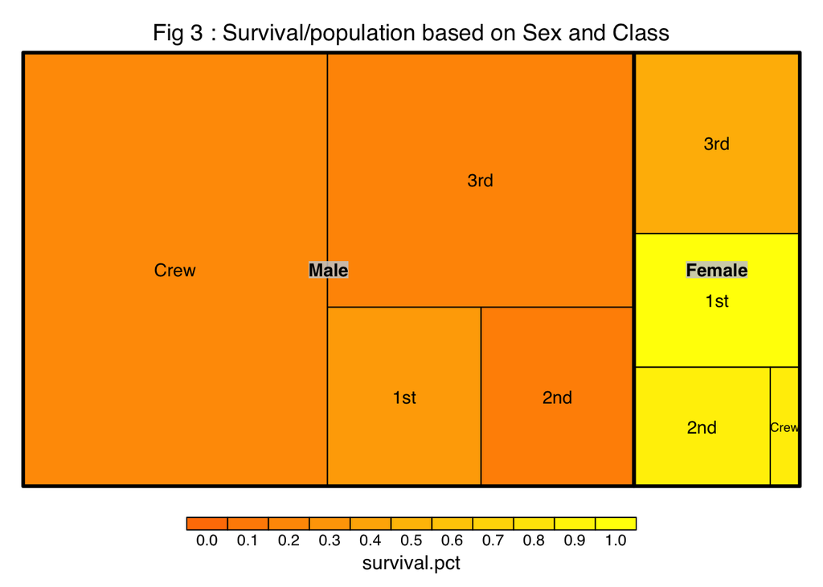

```r
# C ) By Sex and Class #####

by.sex.class<-as.data.frame(d %>%
                        group_by(Sex,Class,Survived) %>%
                        summarise(k = sum(Freq)) %>%
                        mutate(survival.pct = k/sum(k),total = sum(k))%>%
                        filter(Survived == "Yes"))
treemap(by.sex.class,
        index=c("Sex","Class"),
        vSize="total",
        vColor="survival.pct",
        type="value",
        range = c(0,1),
        title = "Fig 3 : Survival/population based on Sex and Class",
        palette=rainbow(10, s = 1, v = 1, start = 0, end = 1/6)
)
```

As we can see form the above tree graph and from what we have seen in earlier graphs, females were given higher priority than men in the evacuation. But there is a difference in the survival percentage when it comes between various classes. People in higher classes(crew, 1st class) were given higher priority to evacuate as compared to people in lower classes(2nd and 3rd).

#### D) Tree map By Age, Sex and Class

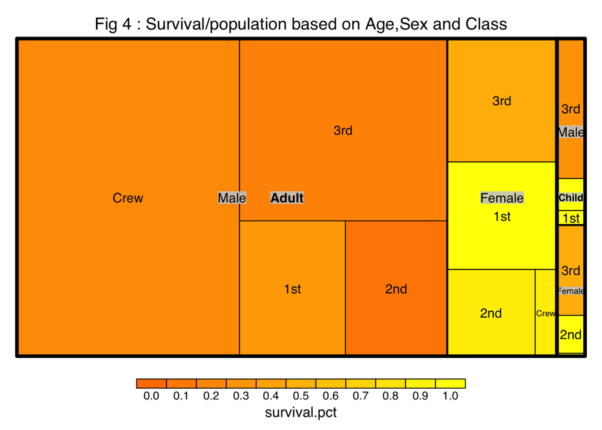

```r
# D) By Age, Sex and Class #####

by.age.sex.class<-as.data.frame(d %>%
                              group_by(Age,Sex,Class,Survived) %>%
                              summarise(k = sum(Freq)) %>%
                              mutate(survival.pct = k/sum(k),total = sum(k))%>%
                              filter(Survived == "Yes"))


treemap(by.age.sex.class,
        index=c("Age","Sex","Class"),
        vSize="total",
        vColor="survival.pct",
        type="value",
        range = c(0,1),
        title = "Fig 4 : Survival/population based on Age,Sex and Class",
        palette=rainbow(n = 10, s = 1, v = 1, start = 0,end = 1/6)
)
```

The above tree graph give a detailed view of the survival percentage among the people on-board the Titanic. As established earlier, women and children were given had a higher survival percentage and people who were from upper classes also had a higer survival percentage. The above graph also confirm this and further shows that womne and children in higher classes had a much higher survival percentage as compared to women and children in lower classes.

### Excercise 2 : Baby Names Graph Streams

#### 1) Top Names :

```r
# 1) Top Names ####

babynames %>%
  group_by(year) %>%
   top_n(1,n) -> top.names

streamgraph(top.names, "name", "n", "year") %>%
  sg_fill_brewer("Spectral") %>%
  sg_axis_x(tick_units = "year", tick_interval = 10, tick_format = "%Y")
```

[interactive chart not shown]

The above graph gives the top names of babies,both male and female for each year since 1880. The graph shows that ‘Mary’ and ‘Michael’ were the most popular names for the largest time span. most of the names reappeared in the graph after a few years.

#### 2) Top name Female :

```r
# 2) Top name Female #####

babynames %>%
  filter(sex=="F",
         name %in% top.names$name) -> top.names.female

streamgraph(top.names.female, "name", "n", "year") %>%
  sg_fill_brewer("Spectral") %>%
  sg_axis_x(tick_units = "year", tick_interval = 10, tick_format = "%Y")
```

[interactive chart not shown]

For only the female names, “Mary” and “Linda” have always been very popular names throughout this timeline. Over in the 21st century, other names like “Sophia” and “Isabella” got more popular.

#### 3) Top name Male :

```r
# 3) Top name Male #####

babynames %>%
  filter(sex=="M",
         name %in% top.names$name) -> top.names.male

streamgraph(top.names.male, "name", "n", "year") %>%
  sg_fill_brewer("Spectral") %>%
  sg_axis_x(tick_units = "year", tick_interval = 10, tick_format = "%Y")
```

[interactive chart not shown]

For the male names as shown above, the names “Robert” and “David” seem to have been the most popular in this timeline. “James” and “Michael” have been mostly the second choice of males baby names, but over the recent years the name “Jacob” has become popular for babies.